# Fitting Prediction and Confidence Intervals

Gary Mitchell

3/5/2021

## Avoiding point estimates

As we have previously discussed, when we fit a regression model, we obtain an expression of the form:

$$\hat{y} = \beta_0 + \beta_1 x_1 + \dots
+ \beta_n x_n$$
Any values calculated with this *regression equation* are only *estimates* of the actual value. These estimates may or may not represent accurate predictions of the actual $y$ value depending on the standard error of the regression.

To put this into context, assume that we are constructing a model to estimate the company’s annual sales given territory population and a number of other variables. Assume that the model produces an estimate of total year revenues of $20 million and that you pass the *estimate* along to senior management.

Of course, the $20 million was only one possible outcome. Now, let’s say that the actual sales turn out to be $12 million. You’re not going to be a very popular person with management at that point (assuming you still have your job). It’s pretty clear that management would not be happy with your overestimating company performance by 67%. On the other hand, you probably wouldn’t be much more popular if the actual sales had come in at $28 million; management might have been able to make very different decisions had you not *underestimated* sales by 29%.

So, how do we avoid our date with unemployment? First, we avoid providing point estimates, instead offering *prediction* intervals. Second, we foster a cultural change in the organization getting every focused on using intervals instead of point estimates (that will always be wrong except by accident).

## Prediction and Confidence Intervals

It turns out that producing prediction and confidence intervals is very easy using R. The bigger challenge, perhaps, is understanding the difference between *prediction* and *confidence* intervals.

### Confidence vs. Prediction Intervals in Statistics

When we fit a regression model, we *choose* estimates that minimize the squared errors from the predicted values made using the regression model. In other words, we do not actually *know* the actual regression coefficients (e.g. $\beta_0, \beta_1, \dots$), so we *estimate* their values. Then, using these *estimated coefficients*, we estimate a predicted value. However, this is just one possible prediction that could have been made and we can construct a *confidence* interval to help us understand the range of possible predictions. This is analagous in concept to the of the confidence interval of the population mean in descriptive statistics.

Let’s say we have a 100 observation sample of heights for american men. The frequency distribution below suggests that the heights follow a normal distribution (proving this is the case is a bit beyond the scope of this course).

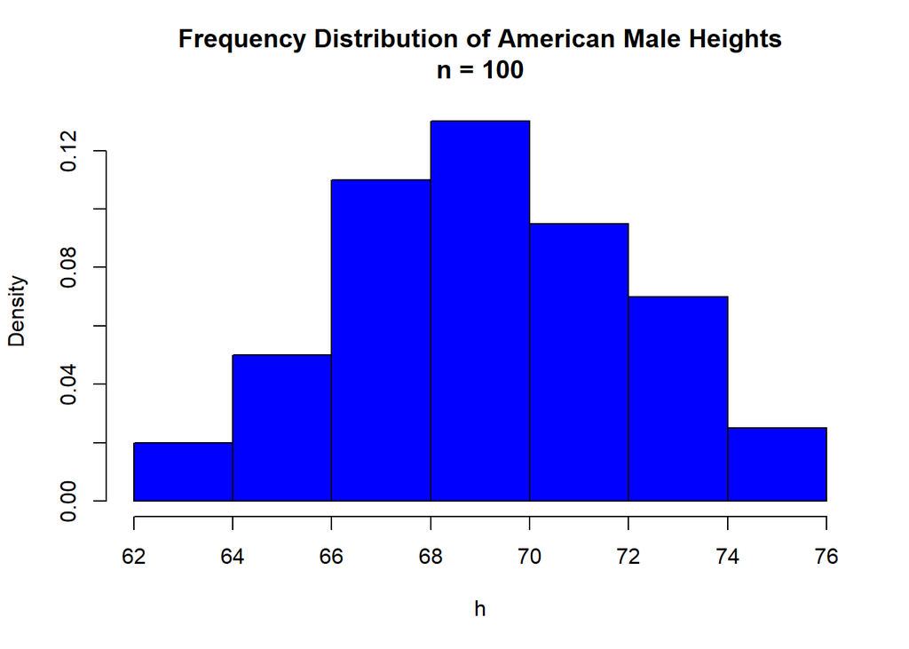

From the sample, we calculate that the average american male stands approximately 68.99 inches tall with a standard deviation of 2.94 inches. We can superimpose the density function for a normal distribution *assuming* $\mu = 68.99$ and $\sigma = 2.94$:

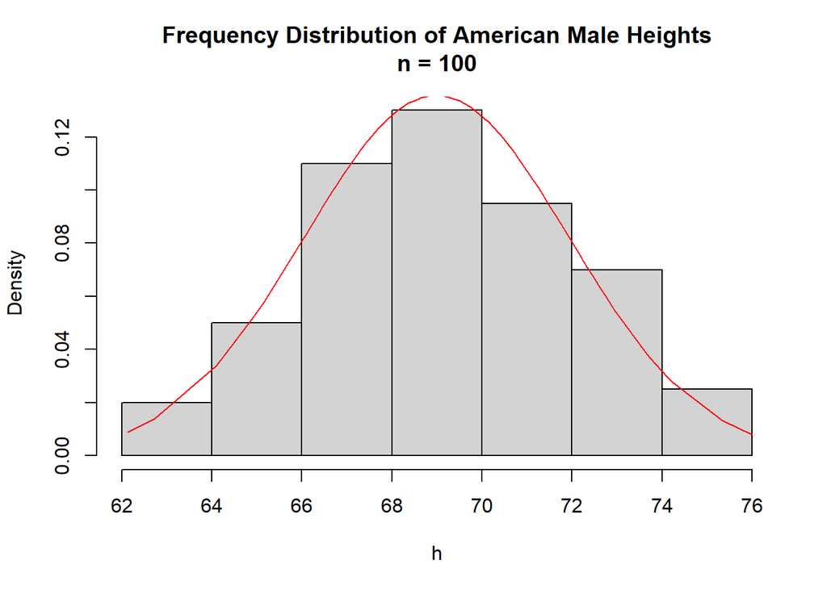

Now, what we have *really* calculated is $\bar{x} = 68.99$, i.e. the *sample* mean which we treat as an estimate of the *population* mean. However, we don’t really *know* the population mean, $\mu$, the actual average height of american males. To find $\mu$, we would need to include the height of *every* American male in our mean calculation.

Clearly, this is impractical for large populations. So, we treat the *sample* mean as the best estimate (i.e. the most likely value) of the population mean, although, we still cannot say that $\mu = 68.99$. What we *can* do is to construct a confidence interval of the possible values of $\mu$.

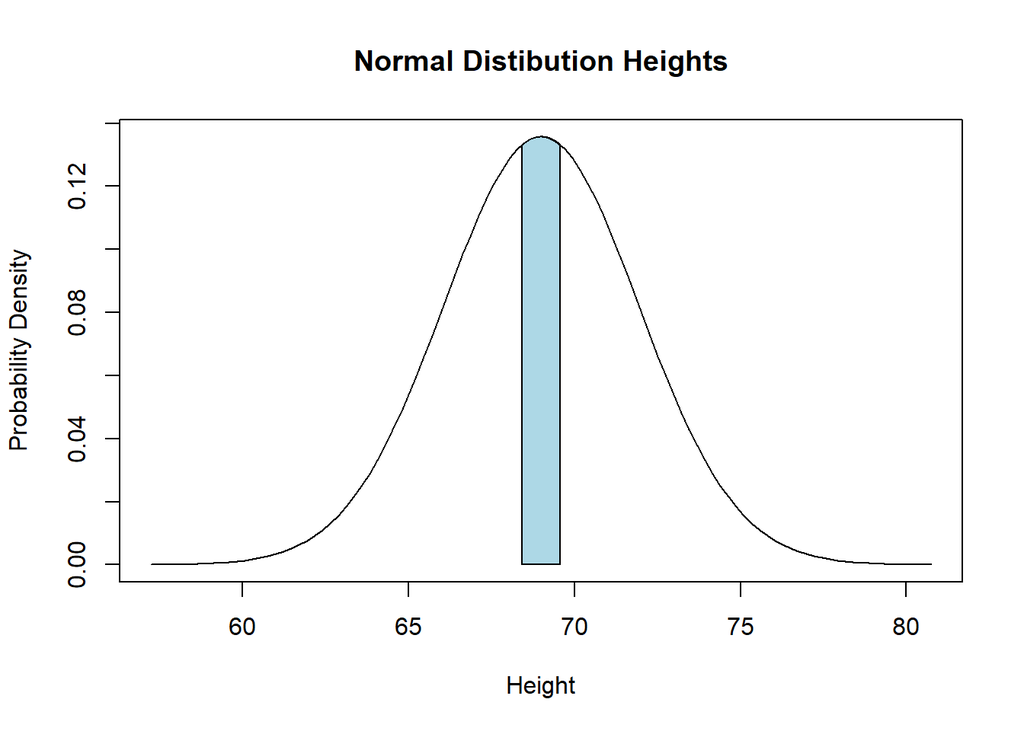

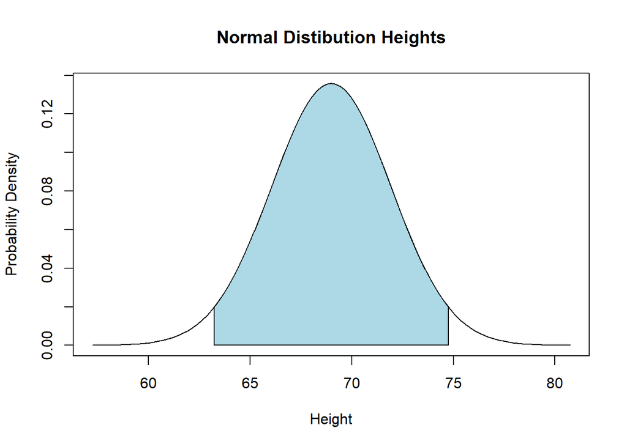

### Confidence vs. Prediction Intervals in Regression Analysis

The confidence and prediction intervals we construct for a regression estimate are analogous to those we just described in descriptive statistics. The primary difference is that for our regression intervals, the *estimate* will be the predicted value $\hat{y}_i$ corresponding to the independent variables $x_{1,i}, \dots, x_{n,i}$ calculated using the regression model, i.e $\hat{y}_i = \beta_0 + \beta_1 x_{1,i} + \dots + \beta_n x_{n,i}$.

Specifically:

- The *prediction* interval represents the boundaries at the desired confidence for a single estimate using the regression model
- The *confidence* interval represents the boundaries for the average predicted value.

For business purposes, we usually want to use the prediction interval. For example, if we are attempting to predict sales, costs, number of customers, etc., we are trying to forecast a single outcome (rather than an average of 100’s of outcomes), so the predicted interval is appropriate.

## Constructing Prediction and Confidence Intervals

R makes it easy to construct these intervals. We can use the built-in *predict* function to produce both. The code below loads the data and constructs the a model of the form:

$$Est\thinspace Page \thinspace Cost =
\beta_1 \sqrt{Distribution}$$

```r
# load page cost data
dat<-read.csv("page costs for R.csv")

# reorder to simplify graphing
dat<-dat[order(dat$Distribution),]

# fit the nonlinear model

model<-lm(Page.Costs ~ 0 + I(sqrt(Distribution)), dat=dat)
print(summary(model))
```

```
##
## Call:
## lm(formula = Page.Costs ~ 0 + I(sqrt(Distribution)), data = dat)
##
## Residuals:
##    Min     1Q Median     3Q    Max
## -42157  -9508     80  10839  42026
##
## Coefficients:
##                       Estimate Std. Error t value Pr(>|t|)
## I(sqrt(Distribution))    888.1       26.0   34.16   <2e-16 ***
## ---
## Signif. codes:  0 '***' 0.001 '**' 0.01 '*' 0.05 '.' 0.1 ' ' 1
##
## Residual standard error: 20140 on 54 degrees of freedom
## Multiple R-squared:  0.9558, Adjusted R-squared:  0.955
## F-statistic:  1167 on 1 and 54 DF,  p-value: < 2.2e-16
```

Here we see the scatterplot of the data with our model’s corresponding predictions:

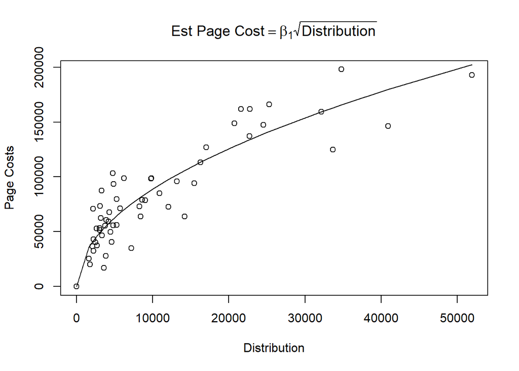

```r
b<-model$coefficients

# include Distribution = 0 into the fitted values
linedat<-data.frame(Distribution=c(0, dat$Distribution),
                    Page.Costs=c(0, dat$Page.Costs))

plot(linedat$Distribution, linedat$Page.Costs,
     ylab='Page Costs',
     xlab='Distribution',
     main=expression("Est Page Cost" == beta[1] * sqrt(Distribution)))
lines(linedat$Distribution, b[1] * sqrt(linedat$Distribution))
```

Now, to construct the prediction or confidence intervals, three necessary conditions must hold:

- The residuals must be normally distributed
- The residuals must not exhibit heteroskedasticity
- The residulas must be independent (i.e. there should be no autocorrelation among the residuals).

These conditions and validation tests are discussed in other tutorials, so I won’t repeat the information here. Instead, I’ll just emphasise that we *must* verify these necessary conditions hold or the prediction and confidence intervals are not reliable (and we should not use the model for making predictions).

As it turns out, two of the three of these do *not* hold for this model. However, for the sake of illustrating how to construct the intervals, we will assume that they all hold.

First, we’ll illustrate the confidence and prediction intervals for our model graphically.

```r
# first we'll fit prediction intervals for the values of
# Distribution that we already have. The values will be
# extracted from our model object automatically

pint<-predict(model, newdata=dat, interval='prediction' )

# now we'll fit confidence intervals for the same values of
# Distribution

head(pint)
```

```
##         fit         lwr      upr
## 1  36021.17 -4411.71409 76454.05
## 27 37417.43 -3019.81329 77854.68
## 36 40485.32    37.89862 80932.75
## 17 41333.68   883.29979 81784.06
## 40 41883.43  1431.10214 82335.75
## 39 42118.18  1665.01086 82571.34
```

```r
cint<-predict(model, newdata=dat, interval='confidence')

head(cint)
```

```
##         fit      lwr      upr
## 1  36021.17 33907.30 38135.04
## 27 37417.43 35221.62 39613.24
## 36 40485.32 38109.48 42861.17
## 17 41333.68 38908.05 43759.31
## 40 41883.43 39425.53 44341.32
## 39 42118.18 39646.51 44589.84
```

Here we have printed just the first several rows of the prediction and confidence intervals generated using *predict*. We see that the general structure is the same for both types of intervals; *predict* provides three values for each set of independent data provided as newdata:

- fit - the value fitted using the regression model
- lwr - the lower bound of the interval
- upr - the upper bound of the interval.

By default, predict produces 95% confidece levels, but we can specify a different confidence value using *level=* in the call to predict. For example, level=0.90 would produce 90 % confidence intervals.

Now we’ll plot the data, add the fitted line, and then add lines for the prediction (green) and confidence (orange) intervals.

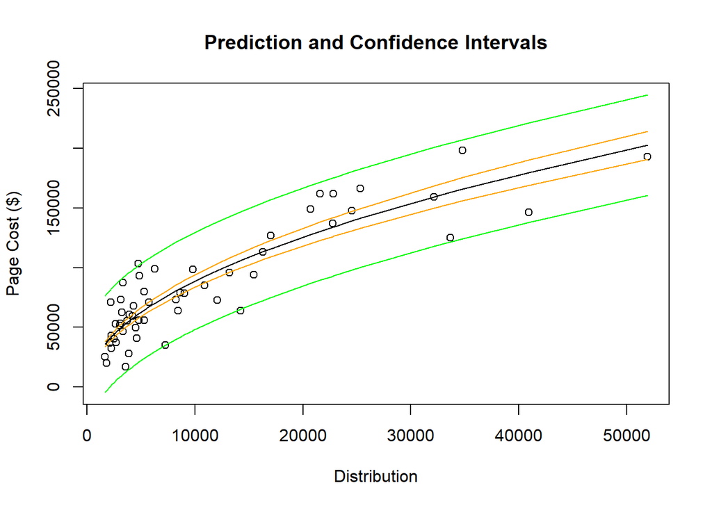

```r
# calculate the range of Page Cost values for the graph. The
# limits need to be large enough to include all values in the
# prediction intervals which include the smallest and largest
# values to be ploted

ylimits<-c(min(pint[,'lwr']), max(pint[,'upr']))

# now, plot the points and fitted values
plot(dat$Distribution, dat$Page.Costs,
     ylim=ylimits,
     xlab='Distribution',
     ylab='Page Cost ($)',
     main='Prediction and Confidence Intervals')
lines(dat$Distribution, pint[,'fit'])

# now, add the prediction and confidence interval lines
lines(dat$Distribution, pint[,'lwr'], col='green')
lines(dat$Distribution, pint[,'upr'], col='green')
lines(dat$Distribution, cint[,'lwr'], col='orange')
lines(dat$Distribution, cint[,'upr'], col='orange')
```

Looking at the graph, we observe a few things:

- The *prediction* interval is much wider than the confidence interval
- Most of the values fall within the prediction interval boundaries.

It makes sense that the confidence interval is narrower than the prediction interval; the confidence interval represents the boundaries of uncertainty for the *mean* whereas the prediction interval represents the boundaries of uncertainty for a single predicted value.

```r
# first, create a data frame with the values we want to use for prediction
newdat<-data.frame(Distribution=c(28500))

# construct the prediction interval
pred<-predict(model, newdata=newdat, level=0.9, interval='prediction')
print(pred)
```

```
##      fit    lwr    upr
## 1 149933 115437 184429
```

So, we we that we are 90% confident that the page cost will be in the interval $[1.1543702\times 10^{5},1.8442899\times 10^{5}]$. To make multiple predictions at once, we simply include multiple values for the independent variables:

```r
# first, create a data frame with the values we want to use for prediction
newdat<-data.frame(Distribution=c(28500, 37000))

# construct the prediction interval
pred<-predict(model, newdata=newdat, level=0.9, interval='prediction')
print(pred)
```

```
##        fit      lwr      upr
## 1 149933.0 115437.0 184429.0
## 2 170834.5 136106.1 205562.9
```

Constructing confidence intervals only requires us to chang ethe interval=‘prediction’ argument to interval=‘confidence’:

```r
# first, create a data frame with the values we want to use for prediction
newdat<-data.frame(Distribution=c(28500, 37000))

# construct the prediction interval
pred<-predict(model, newdata=newdat, level=0.9, interval='confidence')
print(pred)
```

```
##        fit      lwr      upr
## 1 149933.0 142588.3 157277.7
## 2 170834.5 162466.0 179203.1
```